# Supervised Learning - Foundations Project: ReCell

Furthermore, we can see that the mean battery capacity of these devices is around 4276 mAh, and the mean weight is around 247 grams. This information could be relevant to ReCell's refurbishing process as they could focus on upgrading the battery capacity and reducing the device's weight to improve the overall user experience.

Overall, ReCell can use this information to make data-driven decisions in their refurbishing process and inventory management, and focus on the most in-demand brands and specifications for larger-screen devices.

**BA5 : Devices offering great selfie cameras > 8MP with screen size greater than 6in ?**

```python
large_screen_selfie = data[(data['screen_size'] >= 15.24) & (data['selfie_camera_mp']>8) ].shape[0]
large_screen_selfie
```

```
527
```

```python
large_screen_selfie = data[(data['screen_size'] >= 15.24) & (data['selfie_camera_mp']>8) ]  # Filter the data to only include these phones specs
large_selfie_brand = large_screen_selfie['brand_name'].value_counts().head()       # top 5 brands
large_selfie_brand
```

```
Huawei     83
Vivo       65
Oppo       64
Xiaomi     54
Samsung    44
Name: brand_name, dtype: int64
```

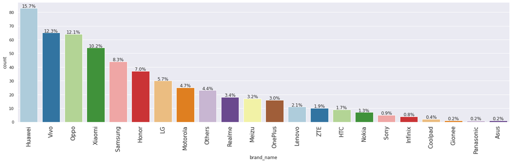

```python
labeled_barplot(large_screen_selfie, "brand_name", perc=True);
```

**Analysis:**

- There is a total of : 527 refurbished phones meeting the specification of screen size > 6inches and with a selfie camera > 8MP.
- The highest % share of devices are from Huawei marking 83 units in ReCell.

**Mean Used Price of Each Brand Device**

```python
brand_price_mean = data.groupby(['brand_name'])['normalized_used_price'].mean().sort_values(ascending=False)
print(brand_price_mean)
```

```
brand_name
OnePlus       5.152165
Apple         5.004553
Google        4.885651
Vivo          4.778147
Oppo          4.755252
Xiaomi        4.710581
Honor         4.665257
Huawei        4.654566
Meizu         4.622101
Realme        4.594316
Sony          4.537851
Asus          4.510720
Samsung       4.466590
Motorola      4.426133
HTC           4.414975
Coolpad       4.399726
Infinix       4.391207
Lenovo        4.379596
ZTE           4.368095
Gionee        4.330395
BlackBerry    4.314155
LG            4.296958
Panasonic     4.218675
Acer          4.217408
Microsoft     4.205679
Others        4.173466
Alcatel       3.970264
XOLO          3.931499
Nokia         3.911802
Lava          3.854529
Karbonn       3.774956
Micromax      3.761856
Spice         3.694512
Celkon        3.230888
Name: normalized_used_price, dtype: float64
```

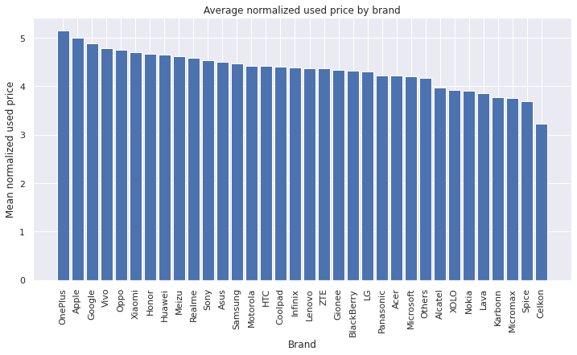

```python
# Plot the result
plt.figure(figsize=(12, 6))
plt.bar(brand_price_mean.index, brand_price_mean.values)
plt.xticks(rotation=90)
plt.xlabel('Brand')
plt.ylabel('Mean normalized used price')
plt.title('Average normalized used price by brand')
plt.show()
```

**Key Statistical Analysis:**

From a business perspective, this information can be useful for ReCell in several ways. For example, ReCell can use this data to determine which brands to focus on when acquiring inventory, which brands to offer better pricing or promotions for, and which brands to avoid due to poor resale value.

**Normalized used price of the devices among different release years for ReCell**

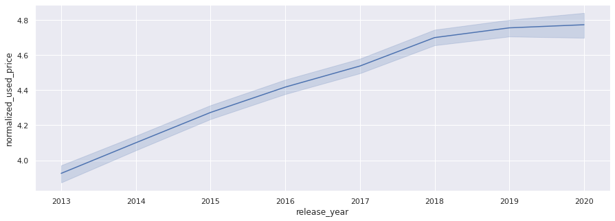

```python
plt.figure(figsize=(15, 5))
sns.lineplot(x="release_year", y="normalized_used_price", data=data);
```

**Analysis :**

From the above plot, it can be infered that the price of refurbished devices keeps increasing over years. The newer the release year the higher the price

### **Multivariate Analysis**

**List the normalized used price of devices in ReCell by its OS and Brandname**

```
         os  brand_name  normalized_used_price
0   Android        Acer               4.201572
1   Android     Alcatel               4.075883
2   Android        Asus               4.510720
3   Android  BlackBerry               4.541266
4   Android      Celkon               3.612172
5   Android     Coolpad               4.399726
6   Android      Gionee               4.330395
7   Android      Google               4.885651
8   Android         HTC               4.420375
9   Android       Honor               4.665257
10  Android      Huawei               4.662174
11  Android     Infinix               4.391207
12  Android     Karbonn               3.774956
13  Android          LG               4.315097
```

[output cut: 75 more lines]

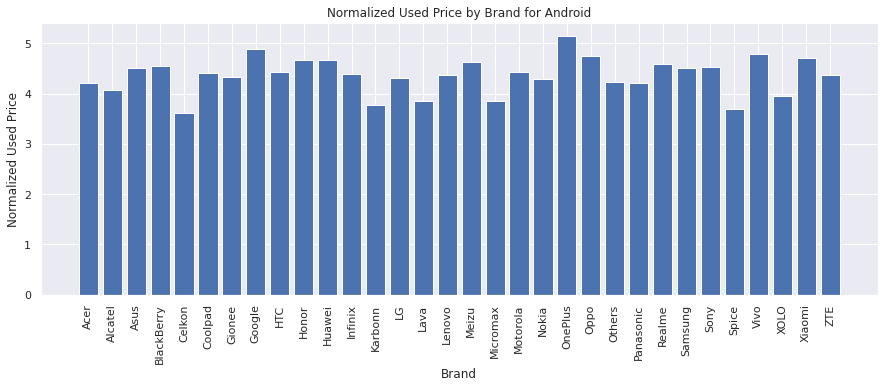

```
Others devices:
    brand_name  normalized_used_price
32        Acer               5.066007
33     Alcatel               3.010894
34       Apple               5.581025
35  BlackBerry               4.124896
36      Celkon               2.468321
37          LG               3.707428
38    Micromax               2.573279
39       Nokia               3.286766
40      Others               3.126779
41     Samsung               3.567050
42         ZTE               3.764451
```

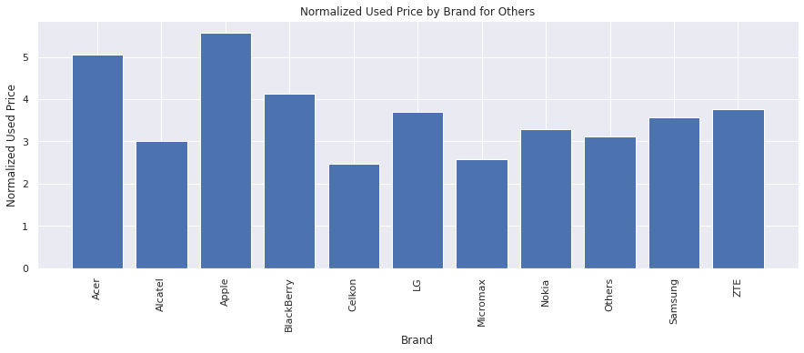

```
Windows devices:
   brand_name  normalized_used_price
43       Acer               4.173170
44        HTC               4.222345
45     Huawei               3.707377
46       Lava               3.848657
47   Micromax               3.820427
48  Microsoft               4.205679
49      Nokia               4.232906
50     Others               4.053855
51    Samsung               4.407216
52       XOLO               3.656354
```

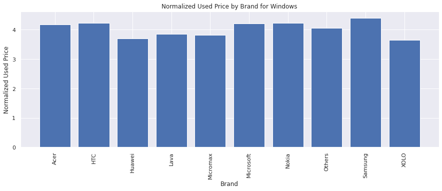

```
iOS devices:
   brand_name  normalized_used_price
53      Apple               4.956514
```

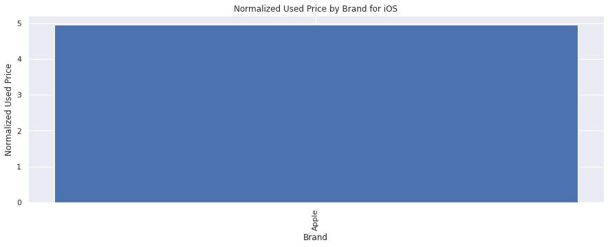

```python
# Define a dictionary mapping each OS to its order
os_order = {'Android': 0, 'Others': 1, 'Windows': 2, 'iOS': 3}

# Group by OS and brand_name and calculate mean of normalized_used_price
avg_price_by_os_brand = data.groupby(['os', 'brand_name'])['normalized_used_price'].mean().reset_index()

# Sort the resulting dataframe by OS order and mean price
sorted_avg_price_by_os_brand = avg_price_by_os_brand.sort_values(['os', 'normalized_used_price'],
                                                                 key=lambda x: x.map(os_order))

'''
use the .loc method to select only the columns of interest in the order intended
in the sorted_avg_price_by_os_brand dataframe
sinc we want all the rows, we use te : for the rowlabel of the syntax
'''
selected_columns = ['os', 'brand_name', 'normalized_used_price']
sorted_avg_price_by_os_brand = sorted_avg_price_by_os_brand.loc[:, selected_columns]

# Print the sorted dataframe
print(sorted_avg_price_by_os_brand)

# Group by OS and display brand names and prices for each OS
for os_name in os_order:
    os_data = sorted_avg_price_by_os_brand[sorted_avg_price_by_os_brand['os'] == os_name]
    os_data = os_data[['brand_name', 'normalized_used_price']]
    print(f"\n{os_name} devices:\n{os_data}")

    # Plot the normalized used price by brand for each OS
    plt.figure(figsize=(15,5))
    plt.bar(os_data['brand_name'], os_data['normalized_used_price'])
    plt.xticks(rotation=90)
    plt.title(f'Normalized Used Price by Brand for {os_name}')
    plt.xlabel('Brand')
    plt.ylabel('Normalized Used Price')
    plt.show()
```

**Analysis of Used Price in Euro :**

## Data Preprocessing

- Missing value treatment. From the initial steps above, we found 6 columns tht requires imputing
- Feature engineering (if needed)
- Outlier detection and treatment (if needed)
- Preparing data for modeling
- Any other preprocessing steps (if needed)

### *1. Missing Value Treatment*

*Create a copy of the data*

```python
# creating a copy of the data to avoid any changes to original data
df = data.copy()
```

*Convert all object data types to categorical types*

```python
# converting initial object data type to categorical data tpes.
df["brand_name"] = df["brand_name"].astype("category")
df["os"] = df["os"].astype("category")
df["4g"] = df["4g"].astype("category")
df["5g"] = df["5g"].astype("category")
```

```python
#validate the data types after conversion

df.info()
```

```
<class 'pandas.core.frame.DataFrame'>
RangeIndex: 3454 entries, 0 to 3453
Data columns (total 15 columns):
 #   Column                 Non-Null Count  Dtype
---  ------                 --------------  -----
 0   brand_name             3454 non-null   category
 1   os                     3454 non-null   category
 2   screen_size            3454 non-null   float64
 3   4g                     3454 non-null   category
 4   5g                     3454 non-null   category
 5   main_camera_mp         3275 non-null   float64
 6   selfie_camera_mp       3452 non-null   float64
 7   int_memory             3450 non-null   float64
 8   ram                    3450 non-null   float64
 9   battery                3448 non-null   float64
 10  weight                 3447 non-null   float64
 11  release_year           3454 non-null   int64
 12  days_used              3454 non-null   int64
 13  normalized_used_price  3454 non-null   float64
 14  normalized_new_price   3454 non-null   float64
dtypes: category(4), float64(9), int64(2)
memory usage: 312.2 KB
```

*Imputing all Nan values with Median*

```python
# imputing all NaN missing values with median of the columns grouped by release year and brand name
'''
uses the transform() method to apply the imputation to all columns in cols_to_impute at once.
df.groupby([ "release_year", "brand_name"])[col] groups the data by release year and brand name
and selects the current column col.

'''
#list all the columns tht needs to be imputed with the median
cols_to_impute = [
    "main_camera_mp",
    "weight",
    "battery",
    "int_memory",
    "ram",
    "selfie_camera_mp",
]

for col in cols_to_impute:
    df[col] = df.groupby([ "release_year", "brand_name"])[col].transform(
        lambda x: x.fillna(x.median())
    )
```

```python
# validate if there are still missing values after he fillna
df.isnull().sum()
```

```
brand_name                 0
os                         0
screen_size                0
4g                         0
5g                         0
main_camera_mp           179
selfie_camera_mp           2
int_memory                 0
ram                        0
battery                    6
weight                     7
release_year               0
days_used                  0
normalized_used_price      0
normalized_new_price       0
dtype: int64
```

```python
'''
There are still missing values.
Let's impute these missing values with median of the columns grouped by just brand name now
'''

cols_to_impute = [
    "main_camera_mp",
    "selfie_camera_mp",
    "battery",
    "weight",
]

for col in cols_to_impute:
    df[col] = df.groupby('brand_name')[col].transform(
        lambda x: x.fillna(x.median())
    )
```

```python
# re-validate missing values
df.isnull().sum()
```

```
brand_name                0
os                        0
screen_size               0
4g                        0
5g                        0
main_camera_mp           10
selfie_camera_mp          0
int_memory                0
ram                       0
battery                   0
weight                    0
release_year              0
days_used                 0
normalized_used_price     0
normalized_new_price      0
dtype: int64
```

```python
'''
There are still missing values. 10 for main_camera_mp
'''
# using fillna for single column only

df["main_camera_mp"] = df["main_camera_mp"].fillna(df["main_camera_mp"].median())
```

```python
# re-validate for missing values
df.isnull().sum()
```

```
brand_name               0
os                       0
screen_size              0
4g                       0
5g                       0
main_camera_mp           0
selfie_camera_mp         0
int_memory               0
ram                      0
battery                  0
weight                   0
release_year             0
days_used                0
normalized_used_price    0
normalized_new_price     0
dtype: int64
```

```python
# Display the new data copy after all the impute exercse
df
```

|  | brand_name | os | screen_size | 4g | 5g | main_camera_mp | selfie_camera_mp | int_memory | ram | battery | weight | release_year | days_used | normalized_used_price | normalized_new_price |
| --- | --- | --- | --- | --- | --- | --- | --- | --- | --- | --- | --- | --- | --- | --- | --- |
| 0 | Honor | Android | 14.50 | yes | no | 13.0 | 5.0 | 64.0 | 3.0 | 3020.0 | 146.0 | 2020 | 127 | 4.307572 | 4.715100 |
| 1 | Honor | Android | 17.30 | yes | yes | 13.0 | 16.0 | 128.0 | 8.0 | 4300.0 | 213.0 | 2020 | 325 | 5.162097 | 5.519018 |
| 2 | Honor | Android | 16.69 | yes | yes | 13.0 | 8.0 | 128.0 | 8.0 | 4200.0 | 213.0 | 2020 | 162 | 5.111084 | 5.884631 |
| 3 | Honor | Android | 25.50 | yes | yes | 13.0 | 8.0 | 64.0 | 6.0 | 7250.0 | 480.0 | 2020 | 345 | 5.135387 | 5.630961 |
| 4 | Honor | Android | 15.32 | yes | no | 13.0 | 8.0 | 64.0 | 3.0 | 5000.0 | 185.0 | 2020 | 293 | 4.389995 | 4.947837 |
| ... | ... | ... | ... | ... | ... | ... | ... | ... | ... | ... | ... | ... | ... | ... | ... |
| 3449 | Asus | Android | 15.34 | yes | no | 13.0 | 8.0 | 64.0 | 6.0 | 5000.0 | 190.0 | 2019 | 232 | 4.492337 | 6.483872 |
| 3450 | Asus | Android | 15.24 | yes | no | 13.0 | 8.0 | 128.0 | 8.0 | 4000.0 | 200.0 | 2018 | 541 | 5.037732 | 6.251538 |
| 3451 | Alcatel | Android | 15.80 | yes | no | 13.0 | 5.0 | 32.0 | 3.0 | 4000.0 | 165.0 | 2020 | 201 | 4.357350 | 4.528829 |
| 3452 | Alcatel | Android | 15.80 | yes | no | 13.0 | 5.0 | 32.0 | 2.0 | 4000.0 | 160.0 | 2020 | 149 | 4.349762 | 4.624188 |
| 3453 | Alcatel | Android | 12.83 | yes | no | 13.0 | 5.0 | 16.0 | 2.0 | 4000.0 | 168.0 | 2020 | 176 | 4.132122 | 4.279994 |

3454 rows × 15 columns

*All the missing values has been treated.*

### *2. Feature Engineering*

- Let's create a new column `years_since_release` from the `release_year` column.
- We will consider the year of data collection, 2021, as the baseline (the year this data was collected)
- We will drop the `release_year` column.

```python
df["years_since_release"] = 2021 - df["release_year"]
df.drop(["release_year"], axis=1, inplace=True)
df.head()
```

|  | brand_name | os | screen_size | 4g | 5g | main_camera_mp | selfie_camera_mp | int_memory | ram | battery | weight | days_used | normalized_used_price | normalized_new_price | years_since_release |
| --- | --- | --- | --- | --- | --- | --- | --- | --- | --- | --- | --- | --- | --- | --- | --- |
| 0 | Honor | Android | 14.50 | yes | no | 13.0 | 5.0 | 64.0 | 3.0 | 3020.0 | 146.0 | 127 | 4.307572 | 4.715100 | 1 |
| 1 | Honor | Android | 17.30 | yes | yes | 13.0 | 16.0 | 128.0 | 8.0 | 4300.0 | 213.0 | 325 | 5.162097 | 5.519018 | 1 |
| 2 | Honor | Android | 16.69 | yes | yes | 13.0 | 8.0 | 128.0 | 8.0 | 4200.0 | 213.0 | 162 | 5.111084 | 5.884631 | 1 |
| 3 | Honor | Android | 25.50 | yes | yes | 13.0 | 8.0 | 64.0 | 6.0 | 7250.0 | 480.0 | 345 | 5.135387 | 5.630961 | 1 |
| 4 | Honor | Android | 15.32 | yes | no | 13.0 | 8.0 | 64.0 | 3.0 | 5000.0 | 185.0 | 293 | 4.389995 | 4.947837 | 1 |

```python
df["years_since_release"].describe()
```

```
count    3454.000000
mean        5.034742
std         2.298455
min         1.000000
25%         3.000000
50%         5.500000
75%         7.000000
max         8.000000
Name: years_since_release, dtype: float64
```

### *3. Outlier detection and treatment*

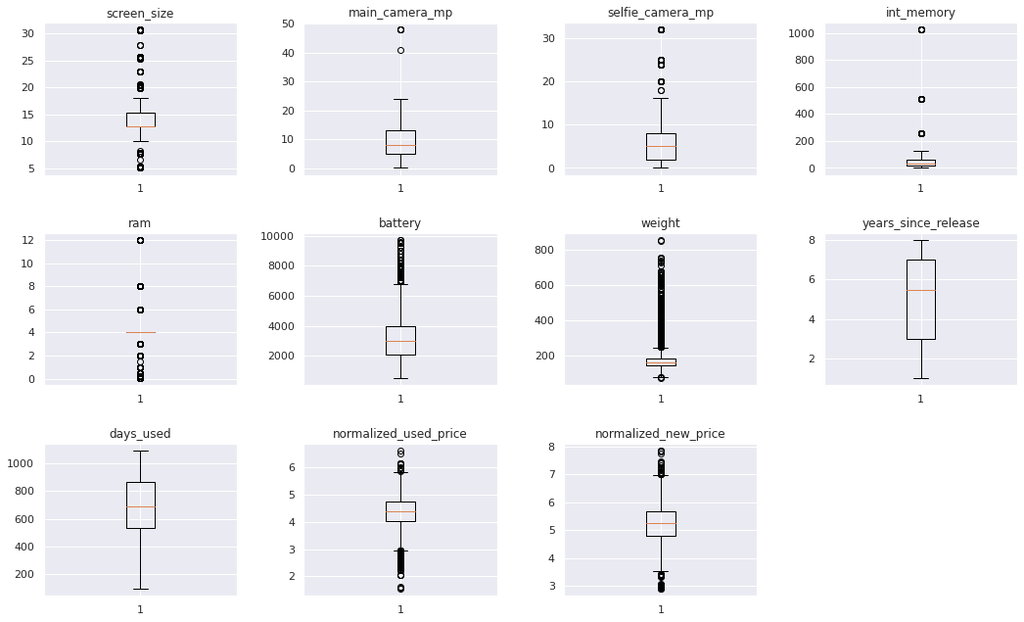

```python
#Let's check for outliers in the data using boxplots
# selecting the numerical columns of data and adding their names in a list

numeric_columns = ['screen_size', 'main_camera_mp', 'selfie_camera_mp', 'int_memory', 'ram', 'battery','weight',
                   'years_since_release','days_used', 'normalized_used_price', 'normalized_new_price']

plt.figure(figsize=(15, 12))

for i, variable in enumerate(numeric_columns):
    plt.subplot(4, 4, i + 1)
    plt.boxplot(df[variable], whis=1.5)
    plt.tight_layout(pad = 2)
    plt.title(variable)

plt.show()
```

**Observation ****

*Student Note : Outliers Treatment*

- Refer to Hands_on_Notebook_ExploratoryDataAnalysis.ipynb and Video Week 4, 4.8 for Outlier treatment.

```python
# Let's treat the outliers in the data set by using the floor and cap/clip method

def treat_outliers(df, col):
    """
    treats outliers in a variable
    col: str, name of the numerical variable
    df: dataframe
    col: name of the column
    """
    Q1 = df[col].quantile(0.25)  # 25th quantile
    Q3 = df[col].quantile(0.75)  # 75th quantile
    IQR = Q3 - Q1
    Lower_Whisker = Q1 - 1.5 * IQR
    Upper_Whisker = Q3 + 1.5 * IQR

    # all the values smaller than Lower_Whisker will be assigned the value of Lower_Whisker
    # all the values greater than Upper_Whisker will be assigned the value of Upper_Whisker
    df[col] = np.clip(df[col], Lower_Whisker, Upper_Whisker)

    return df


def treat_outliers_all(df, col_list):
    """
    treat outlier in all numerical variables
    col_list: list of numerical variables
    df: data frame
    """
    for c in col_list:
        df = treat_outliers(df, c)

    return df
```

```python
# list of columns to treat for outliers
# We will not treat outliers in the ram column as its 25%, 50% and 75% is at 4.0 and doing so
# will remove the variation in the column

treat_out_cols = ["weight", "normalized_new_price", "battery",
                  "int_memory", "selfie_camera_mp", "main_camera_mp", "screen_size"]

# create a new data frame after treating outliers from the df dataframe copy in the colums
df_treated = treat_outliers_all(df, treat_out_cols)
```

**Validate columns to see if outliers were treated**

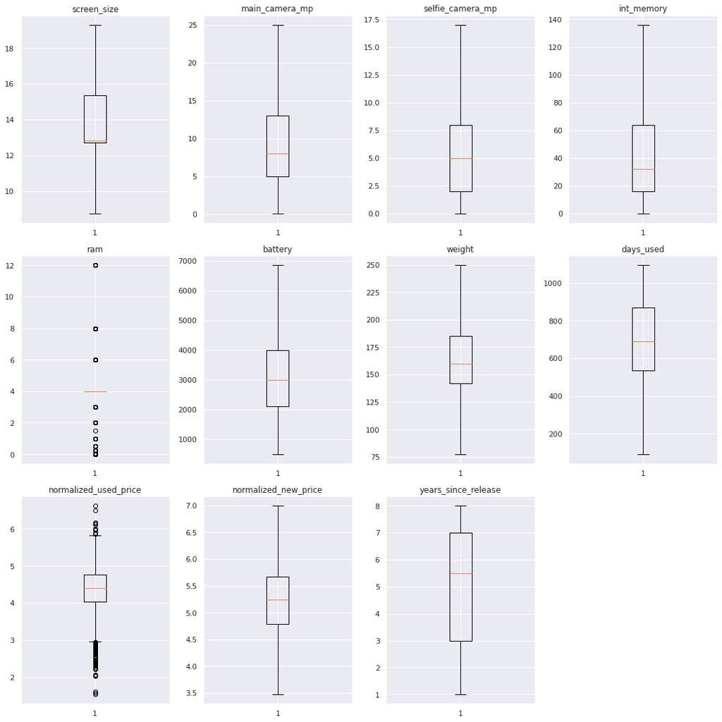

```python
# let's look at the boxplots to see if the outliers have been treated or not

numeric_columns = df_treated.select_dtypes(include=np.number).columns.tolist()

plt.figure(figsize=(15, 15))

for i, variable in enumerate(numeric_columns):
    plt.subplot(3, 4, i + 1)
    plt.boxplot(df[variable], whis=1.5)
    plt.tight_layout()
    plt.title(variable)

plt.show()
```

**All outliers in the independent columns have been treated apart from the ram column**

*We would need to drop this column as after creating dummy var in model building, there will be many columns formed*

```python
df_treated.drop(["brand_name"], axis=1, inplace=True) # drop brand_name column and run the data frame again in EDA
```

### **4. Data Preparation for Modeling**

- We want to predict the normalized price of used devices
- Before we proceed to build a model, we'll have to encode categorical features
- We'll split the data into train and test to be able to evaluate the model that we build on the train data
- We will build a Linear Regression model using the train data and then check it's performance

```python
# defining X and y variables (define the dependent and independent variables)
X = df.drop(["normalized_used_price"], axis=1)
y = df["normalized_used_price"]

print(X.head())     # view independent variables
print(y.head())     # view dependent variables
```

```
        os  screen_size   4g   5g  main_camera_mp  selfie_camera_mp  \
0  Android        14.50  yes   no            13.0               5.0
1  Android        17.30  yes  yes            13.0              16.0
2  Android        16.69  yes  yes            13.0               8.0
3  Android        19.30  yes  yes            13.0               8.0
4  Android        15.32  yes   no            13.0               8.0

   int_memory  ram  battery  weight  days_used  normalized_new_price  \
0        64.0  3.0   3020.0   146.0        127              4.715100
1       128.0  8.0   4300.0   213.0        325              5.519018
2       128.0  8.0   4200.0   213.0        162              5.884631
3        64.0  6.0   6850.0   249.5        345              5.630961
4        64.0  3.0   5000.0   185.0        293              4.947837

   years_since_release
0                    1
1                    1
2                    1
3                    1
4                    1
0    4.307572
1    5.162097
2    5.111084
3    5.135387
4    4.389995
Name: normalized_used_price, dtype: float64
```

```python
# let's add the intercept to data
X = sm.add_constant(X)
```

```python
# creating dummy variables
# The get_dummies() function used creates new columns for each unique value in a categorical variable,
# assigning a value of 1 or 0 to indicate its presence or absence

X = pd.get_dummies(
    X,
    columns=X.select_dtypes(include=["object", "category"]).columns.tolist(),
    drop_first=True,
)
X.head()

'''
In machine learning, numerical values are preferred as input features
because algorithms often require mathematical operations. The astype(float) function call is
used to convert all data types in the X dataframe to float, ensuring that all variables
are numeric and can be used as input features in machine learning models.
'''

# to ensure all variables are of float type
X = X.astype(float)

X.head()
```

|  | const | screen_size | main_camera_mp | selfie_camera_mp | int_memory | ram | battery | weight | days_used | normalized_new_price | years_since_release | os_Others | os_Windows | os_iOS | 4g_yes | 5g_yes |
| --- | --- | --- | --- | --- | --- | --- | --- | --- | --- | --- | --- | --- | --- | --- | --- | --- |
| 0 | 1.0 | 14.50 | 13.0 | 5.0 | 64.0 | 3.0 | 3020.0 | 146.0 | 127.0 | 4.715100 | 1.0 | 0.0 | 0.0 | 0.0 | 1.0 | 0.0 |
| 1 | 1.0 | 17.30 | 13.0 | 16.0 | 128.0 | 8.0 | 4300.0 | 213.0 | 325.0 | 5.519018 | 1.0 | 0.0 | 0.0 | 0.0 | 1.0 | 1.0 |
| 2 | 1.0 | 16.69 | 13.0 | 8.0 | 128.0 | 8.0 | 4200.0 | 213.0 | 162.0 | 5.884631 | 1.0 | 0.0 | 0.0 | 0.0 | 1.0 | 1.0 |
| 3 | 1.0 | 19.30 | 13.0 | 8.0 | 64.0 | 6.0 | 6850.0 | 249.5 | 345.0 | 5.630961 | 1.0 | 0.0 | 0.0 | 0.0 | 1.0 | 1.0 |
| 4 | 1.0 | 15.32 | 13.0 | 8.0 | 64.0 | 3.0 | 5000.0 | 185.0 | 293.0 | 4.947837 | 1.0 | 0.0 | 0.0 | 0.0 | 1.0 | 0.0 |

```python
# splitting the data in 70:30 ratio for train to test data

x_train, x_test, y_train, y_test = train_test_split(X, y, test_size=0.3, random_state=1)
```

```python
print("Number of rows in train data =", x_train.shape[0])
print("Number of rows in test data =", x_test.shape[0])
```

```
Number of rows in train data = 2417
Number of rows in test data = 1037
```

## EDA

- It is a good idea to explore the data once again after manipulating it.
- check the statistical summary of the new outlier corrected (df_treated) dataset to get an overview of the numerical columns of the data
- check if there are missing values in the dataset
- check the unique values of the dataset

```python
# check the statistical summary once again
df_treated.describe(include="all").T
```

|  | count | unique | top | freq | mean | std | min | 25% | 50% | 75% | max |
| --- | --- | --- | --- | --- | --- | --- | --- | --- | --- | --- | --- |
| os | 3454 | 4 | Android | 3214 | NaN | NaN | NaN | NaN | NaN | NaN | NaN |
| screen_size | 3454.0 | NaN | NaN | NaN | 13.551595 | 2.807499 | 8.74 | 12.7 | 12.83 | 15.34 | 19.3 |
| 4g | 3454 | 2 | yes | 2335 | NaN | NaN | NaN | NaN | NaN | NaN | NaN |
| 5g | 3454 | 2 | no | 3302 | NaN | NaN | NaN | NaN | NaN | NaN | NaN |
| main_camera_mp | 3454.0 | NaN | NaN | NaN | 9.586329 | 4.572418 | 0.08 | 5.0 | 8.0 | 13.0 | 25.0 |
| selfie_camera_mp | 3454.0 | NaN | NaN | NaN | 5.96242 | 5.345927 | 0.0 | 2.0 | 5.0 | 8.0 | 17.0 |
| int_memory | 3454.0 | NaN | NaN | NaN | 44.694079 | 39.079988 | 0.01 | 16.0 | 32.0 | 64.0 | 136.0 |
| ram | 3454.0 | NaN | NaN | NaN | 4.03262 | 1.368598 | 0.02 | 4.0 | 4.0 | 4.0 | 12.0 |
| battery | 3454.0 | NaN | NaN | NaN | 3109.100898 | 1212.793754 | 500.0 | 2100.0 | 3000.0 | 4000.0 | 6850.0 |
| weight | 3454.0 | NaN | NaN | NaN | 166.817371 | 38.857747 | 77.5 | 142.0 | 160.0 | 185.0 | 249.5 |
| days_used | 3454.0 | NaN | NaN | NaN | 674.869716 | 248.580166 | 91.0 | 533.5 | 690.5 | 868.75 | 1094.0 |
| normalized_used_price | 3454.0 | NaN | NaN | NaN | 4.364712 | 0.588914 | 1.536867 | 4.033931 | 4.405133 | 4.7557 | 6.619433 |
| normalized_new_price | 3454.0 | NaN | NaN | NaN | 5.234936 | 0.666538 | 3.465277 | 4.790342 | 5.245892 | 5.673718 | 6.998783 |
| years_since_release | 3454.0 | NaN | NaN | NaN | 5.034742 | 2.298455 | 1.0 | 3.0 | 5.5 | 7.0 | 8.0 |

```python
# validate new df has no missing values as required
df_treated.isnull().sum().sum()
```

```
0
```

```python
# check the data types are as required, corrected
df_treated.info()
```

```
<class 'pandas.core.frame.DataFrame'>
RangeIndex: 3454 entries, 0 to 3453
Data columns (total 14 columns):
 #   Column                 Non-Null Count  Dtype
---  ------                 --------------  -----
 0   os                     3454 non-null   category
 1   screen_size            3454 non-null   float64
 2   4g                     3454 non-null   category
 3   5g                     3454 non-null   category
 4   main_camera_mp         3454 non-null   float64
 5   selfie_camera_mp       3454 non-null   float64
 6   int_memory             3454 non-null   float64
 7   ram                    3454 non-null   float64
 8   battery                3454 non-null   float64
 9   weight                 3454 non-null   float64
 10  days_used              3454 non-null   int64
 11  normalized_used_price  3454 non-null   float64
 12  normalized_new_price   3454 non-null   float64
 13  years_since_release    3454 non-null   int64
dtypes: category(3), float64(9), int64(2)
memory usage: 307.5 KB
```

```python
# check te data loaded correctly
df_treated.head()
```

|  | os | screen_size | 4g | 5g | main_camera_mp | selfie_camera_mp | int_memory | ram | battery | weight | days_used | normalized_used_price | normalized_new_price | years_since_release |
| --- | --- | --- | --- | --- | --- | --- | --- | --- | --- | --- | --- | --- | --- | --- |
| 0 | Android | 14.50 | yes | no | 13.0 | 5.0 | 64.0 | 3.0 | 3020.0 | 146.0 | 127 | 4.307572 | 4.715100 | 1 |
| 1 | Android | 17.30 | yes | yes | 13.0 | 16.0 | 128.0 | 8.0 | 4300.0 | 213.0 | 325 | 5.162097 | 5.519018 | 1 |
| 2 | Android | 16.69 | yes | yes | 13.0 | 8.0 | 128.0 | 8.0 | 4200.0 | 213.0 | 162 | 5.111084 | 5.884631 | 1 |
| 3 | Android | 19.30 | yes | yes | 13.0 | 8.0 | 64.0 | 6.0 | 6850.0 | 249.5 | 345 | 5.135387 | 5.630961 | 1 |
| 4 | Android | 15.32 | yes | no | 13.0 | 8.0 | 64.0 | 3.0 | 5000.0 | 185.0 | 293 | 4.389995 | 4.947837 | 1 |

## Model Building - Linear Regression

*Activity Note of Student :*

- *1st run of OLS model, the summary had many phone brandnames from the dummy variable creation.*
- *Hv moved up and dropped the brandname in the data pre-processing part and did a new runtime*

```python
olsmodel = sm.OLS(y_train, x_train).fit()
print(olsmodel.summary())
```

```
                              OLS Regression Results
=================================================================================
Dep. Variable:     normalized_used_price   R-squared:                       0.835
Model:                               OLS   Adj. R-squared:                  0.834
Method:                    Least Squares   F-statistic:                     810.5
Date:                   Fri, 17 Mar 2023   Prob (F-statistic):               0.00
Time:                           15:30:00   Log-Likelihood:                 49.790
No. Observations:                   2417   AIC:                            -67.58
Df Residuals:                       2401   BIC:                             25.07
Df Model:                             15
Covariance Type:               nonrobust
========================================================================================
                           coef    std err          t      P>|t|      [0.025      0.975]
----------------------------------------------------------------------------------------
const                    0.9735      0.055     17.716      0.000       0.866       1.081
screen_size              0.0417      0.004     10.926      0.000       0.034       0.049
main_camera_mp           0.0210      0.002     13.392      0.000       0.018       0.024
selfie_camera_mp         0.0163      0.002      9.441      0.000       0.013       0.020
int_memory               0.0004      0.000      2.272      0.023    5.67e-05       0.001
ram                      0.0232      0.005      4.627      0.000       0.013       0.033
battery               1.627e-06   7.41e-06      0.220      0.826   -1.29e-05    1.62e-05
weight                   0.0015      0.000      5.998      0.000       0.001       0.002
days_used             6.472e-05   3.11e-05      2.080      0.038    3.69e-06       0.000
normalized_new_price     0.4115      0.012     33.644      0.000       0.388       0.436
years_since_release     -0.0114      0.005     -2.396      0.017      -0.021      -0.002
os_Others               -0.0639      0.028     -2.250      0.025      -0.120      -0.008
os_Windows               0.0574      0.037      1.550      0.121      -0.015       0.130
os_iOS                   0.0139      0.046      0.303      0.762      -0.076       0.104
4g_yes                   0.0301      0.016      1.918      0.055      -0.001       0.061
5g_yes                  -0.0502      0.031     -1.604      0.109      -0.112       0.011
==============================================================================
Omnibus:                      215.617   Durbin-Watson:                   1.936
Prob(Omnibus):                  0.000   Jarque-Bera (JB):              426.966
Skew:                          -0.586   Prob(JB):                     1.93e-93
Kurtosis:                       4.692   Cond. No.                     4.07e+04
==============================================================================

Notes:
[1] Standard Errors assume that the covariance matrix of the errors is correctly specified.
[2] The condition number is large, 4.07e+04. This might indicate that there are
strong multicollinearity or other numerical problems.
```

**Interpretation of the Regression Results**

This is an OLS regression summary output for a model with a dependent variable "normalized_used_price" and 15 independent variables.

1. **Adjusted R-squared**: It reflects the fit of the model.
   - Adjusted R-squared values generally range from 0 to 1, where a higher value generally indicates a better fit, assuming certain conditions are met. In our case, the value for adj. R-squared is 0.834, which is good.
   - The R-squared value of 0.835 indicates that 83.5% of the variance in the dependent variable is explained by the independent variables in the model, which is a good fit.
2. **const coefficient:** It is the Y-intercept.
   - It means that if all the predictor variable coefficients are zero, then the expected output (i.e., Y) would be equal to the const coefficient. In our case, the value for const coefficient is 0.9735.
3. The coefficients of each independent variable indicate the strength and direction of their relationship with the dependent variable. For example, the "main_camera_mp" variable has a coefficient of 0.0210, which suggests that a one-unit increase in main_camera_mp is associated with a 0.0210-unit increase in normalized_used_price, holding all other variables constant.
4. The p-values associated with each coefficient suggest whether the relationship between that independent variable and the dependent variable is statistically significant (p-value < 0.05). For example, the variable "os_Others" has a p-value of 0.025, indicating that it is statistically significant in predicting normalized_used_price.

## Model Performance Check

Let's check the performance of the model using different metrics.

- We will be using metric functions defined in sklearn for RMSE, MAE, and R2 .
- We will define a function to calculate MAPE and adjusted R2 .
- We will create a function which will print out all the above metrics in one go.

```python
# function to compute adjusted R-squared
def adj_r2_score(predictors, targets, predictions):
    r2 = r2_score(targets, predictions)
    n = predictors.shape[0]
    k = predictors.shape[1]
    return 1 - ((1 - r2) * (n - 1) / (n - k - 1))


# function to compute MAPE
def mape_score(targets, predictions):
    return np.mean(np.abs(targets - predictions) / targets) * 100


# function to compute different metrics to check performance of a regression model
def model_performance_regression(model, predictors, target):
    """
    Function to compute different metrics to check regression model performance

    model: regressor
    predictors: independent variables
    target: dependent variable
    """

    # predicting using the independent variables
    pred = model.predict(predictors)

    r2 = r2_score(target, pred)  # to compute R-squared
    adjr2 = adj_r2_score(predictors, target, pred)  # to compute adjusted R-squared
    rmse = np.sqrt(mean_squared_error(target, pred))  # to compute RMSE
    mae = mean_absolute_error(target, pred)  # to compute MAE
    mape = mape_score(target, pred)  # to compute MAPE

    # creating a dataframe of metrics
    df_perf = pd.DataFrame(
        {
            "RMSE": rmse,
            "MAE": mae,
            "R-squared": r2,
            "Adj. R-squared": adjr2,
            "MAPE": mape,
        },
        index=[0],
    )

    return df_perf
```

```python
# checking model performance on train set (seen 70% data)
print("Training Performance\n")
olsmodel_train_perf = model_performance_regression(olsmodel, x_train, y_train)
olsmodel_train_perf
```

```
Training Performance
```

|  | RMSE | MAE | R-squared | Adj. R-squared | MAPE |
| --- | --- | --- | --- | --- | --- |
| 0 | 0.237037 | 0.183555 | 0.835082 | 0.833983 | 4.422144 |

```python
# checking model performance on test set (seen 30% data)
print("Test Performance\n")
olsmodel_test_perf = model_performance_regression(olsmodel, x_test, y_test)
olsmodel_test_perf
```

```
Test Performance
```

|  | RMSE | MAE | R-squared | Adj. R-squared | MAPE |
| --- | --- | --- | --- | --- | --- |
| 0 | 0.243524 | 0.187981 | 0.835576 | 0.832997 | 4.591873 |

**Analysis on Training Performance**

- The RMSE value of 0.237 indicates that the average difference between the actual and predicted values is relatively low.
- The MAE value of 0.183555 suggests that the model's predictions on average is off by 0.183555 units.
- The R-squared value of 0.835082 indicates that the model explains 83.5% of the variance in the target variable, which is a decent fit.
- The Adj. R-squared value of 0.833983 is slightly lower than R-squared, suggesting that some of the independent variables may not be relevant for the model.
- The MAPE value of 4.422144 indicates that on average the model's predictions is off by 4.42% of the actual value.

**Analysis on Testing Performance amd in comparison to Training Set**

- The RMSE value of 0.243524 is just slightly higher than the RMSE on the training set, indicating the model is making slightly larger errors on the testing set.
- The MAE value 0.187981 is also slightly higher than the MAE on the training set, suggesting that on average, the model's predictions for the price of a used device is off by 0.187 units on the testing set.
- The R-squared value of 0.835576 on the testing set is almost identical to the R-squared on the training set, indicating that the model is performing well on data that it has not seen.
- The Adj. R-squared value of 0.832997 is slightly lower than R-squared, which could indicate that the model is slightly overfitting the data
- The MAPE value of 4.591873 indicates that, on average, the model's predictions are off by 4.6% of the actual value on the testing set.

**Overall** The given performance metrics suggest that the model has performed well on both the training and test datasets, as the RMSE and MAE values are low and the R-Square is higher. However, the adjusted R-squared values are lower than the original OLS, suggesting that the model needs improvement.

**Note :** If the R-squared and adjusted R-squared values of the training and test models are higher than that of the OLS model, it indicates that the model is performing well. If the values are lower, it suggests that the model needs improvement.

## Checking Linear Regression Assumptions

- In order to make statistical inferences from a linear regression model, it is important to ensure that the assumptions of linear regression are satisfied.

We will be checking the following Linear Regression assumptions:

1. **No Multicollinearity**
2. **Linearity of variables**
3. **Independence of error terms**
4. **Normality of error terms**
5. **No Heteroscedasticity**

### 1. TEST FOR MULTICOLLINEARITY

General Rule of thumb:

- If VIF is between 1 and 5, then there is low multicollinearity.
- If VIF is between 5 and 10, we say there is moderate multicollinearity.
- If VIF is exceeding 10, it shows signs of high multicollinearity.

**Let's define a function to check VIF.**

```python
def checking_vif(predictors):
    vif = pd.DataFrame()
    vif["feature"] = predictors.columns

    # calculating VIF for each feature
    vif["VIF"] = [
        variance_inflation_factor(predictors.values, i)
        for i in range(len(predictors.columns))
    ]
    return vif
```

```python
checking_vif(x_train)
```

|  | feature | VIF |
| --- | --- | --- |
| 0 | const | 129.029159 |
| 1 | screen_size | 5.026353 |
| 2 | main_camera_mp | 2.148928 |
| 3 | selfie_camera_mp | 3.615311 |
| 4 | int_memory | 2.149685 |
| 5 | ram | 2.061689 |
| 6 | battery | 3.532332 |
| 7 | weight | 4.340216 |
| 8 | days_used | 2.579938 |
| 9 | normalized_new_price | 2.801817 |
| 10 | years_since_release | 5.073917 |
| 11 | os_Others | 1.327395 |
| 12 | os_Windows | 1.023375 |
| 13 | os_iOS | 1.095396 |
| 14 | 4g_yes | 2.297755 |
| 15 | 5g_yes | 1.710981 |

**Observation**

1. There is some degree of multicollinearity in the model. The "const" feature has a very high VIF value of 129.029, which suggests that it may be highly correlated with one or more other features in the model.
2. The "screen_size" feature has a VIF value of 5.026353, and the "years_since_release" has a VIF value of 5.073917, suggesting that they may also be highly correlated with other features in the model.
3. We will ignore the VIF values for dummy variables and the constant (intercept)

Note : Lets fix the multicollinearity

To remove multicollinearity : **STEPS**

- Drop every column one by one that has a VIF score greater than 5.
- Look at the adjusted R-squared and RMSE of all these models.
- Drop the variable that makes the least change in adjusted R-squared.
- Check the VIF scores again.
- Continue till you get all VIF scores under 5.

**Now let's define a function that will help us do this.**

```python
def treating_multicollinearity(predictors, target, high_vif_columns):
    """
    Checking the effect of dropping the columns showing high multicollinearity
    on model performance (adj. R-squared and RMSE)

    predictors: independent variables
    target: dependent variable
    high_vif_columns: columns having high VIF
    """
    # empty lists to store adj. R-squared and RMSE values
    adj_r2 = []
    rmse = []

    # build ols models by dropping one of the high VIF columns at a time
    # store the adjusted R-squared and RMSE in the lists defined previously
    for cols in high_vif_columns:
        # defining the new train set
        train = predictors.loc[:, ~predictors.columns.str.startswith(cols)]

        # create the model
        olsmodel = sm.OLS(target, train).fit()

        # adding adj. R-squared and RMSE to the lists
        adj_r2.append(olsmodel.rsquared_adj)
        rmse.append(np.sqrt(olsmodel.mse_resid))

    # creating a dataframe for the results
    temp = pd.DataFrame(
        {
            "col": high_vif_columns,
            "Adj. R-squared after_dropping col": adj_r2,
            "RMSE after dropping col": rmse,
        }
    ).sort_values(by="Adj. R-squared after_dropping col", ascending=False)
    temp.reset_index(drop=True, inplace=True)

    return temp
```

```python
col_list = ["screen_size","years_since_release"]

res = treating_multicollinearity(x_train, y_train, col_list)
res
```

|  | col | Adj. R-squared after_dropping col | RMSE after dropping col |
| --- | --- | --- | --- |
| 0 | years_since_release | 0.833725 | 0.238060 |
| 1 | screen_size | 0.825873 | 0.243616 |

*Analysis :*

**Conlusion** :

- This suggests that these features are important for predicting the target variable and should not be removed from the model.
- Dropping screen_size will have the maximum impact on the predictive power of the model, so we will drop year-since-release and check VIF again.

```python
col_to_drop = "years_since_release"
x_train2 = x_train.loc[:, ~x_train.columns.str.startswith(col_to_drop)]
x_test2 = x_test.loc[:, ~x_test.columns.str.startswith(col_to_drop)]

# Check VIF now
vif = checking_vif(x_train2)
print("VIF after dropping ", col_to_drop)
vif
```

```
VIF after dropping  years_since_release
```

|  | feature | VIF |
| --- | --- | --- |
| 0 | const | 126.070999 |
| 1 | screen_size | 4.954025 |
| 2 | main_camera_mp | 2.139245 |
| 3 | selfie_camera_mp | 3.107275 |
| 4 | int_memory | 2.104055 |
| 5 | ram | 2.057087 |
| 6 | battery | 3.456675 |
| 7 | weight | 4.326849 |
| 8 | days_used | 1.857758 |
| 9 | normalized_new_price | 2.495403 |
| 10 | os_Others | 1.327337 |
| 11 | os_Windows | 1.023349 |
| 12 | os_iOS | 1.086555 |
| 13 | 4g_yes | 1.926797 |
| 14 | 5g_yes | 1.687101 |

- Dropping years_since_release has set the VIF of screen_sizeto 4.954025 (below 5).
- Hence we have dealt with multicollinearity in the data and the assumption is satisfied
- Let rebuild the model summary again

```python
olsmod1 = sm.OLS(y_train, x_train2).fit()
print(olsmod1.summary())
```

```
                              OLS Regression Results
=================================================================================
Dep. Variable:     normalized_used_price   R-squared:                       0.835
Model:                               OLS   Adj. R-squared:                  0.834
Method:                    Least Squares   F-statistic:                     866.3
Date:                   Fri, 17 Mar 2023   Prob (F-statistic):               0.00
Time:                           15:32:18   Log-Likelihood:                 46.904
No. Observations:                   2417   AIC:                            -63.81
Df Residuals:                       2402   BIC:                             23.05
Df Model:                             14
Covariance Type:               nonrobust
========================================================================================
                           coef    std err          t      P>|t|      [0.025      0.975]
----------------------------------------------------------------------------------------
const                    0.9535      0.054     17.538      0.000       0.847       1.060
screen_size              0.0428      0.004     11.284      0.000       0.035       0.050
main_camera_mp           0.0212      0.002     13.570      0.000       0.018       0.024
selfie_camera_mp         0.0178      0.002     11.142      0.000       0.015       0.021
int_memory               0.0005      0.000      2.647      0.008       0.000       0.001
ram                      0.0226      0.005      4.514      0.000       0.013       0.032
battery               4.226e-06   7.34e-06      0.576      0.565   -1.02e-05    1.86e-05
weight                   0.0015      0.000      5.869      0.000       0.001       0.002
days_used             2.527e-05   2.64e-05      0.956      0.339   -2.66e-05    7.71e-05
normalized_new_price     0.4018      0.012     34.775      0.000       0.379       0.424
os_Others               -0.0643      0.028     -2.263      0.024      -0.120      -0.009
os_Windows               0.0569      0.037      1.536      0.125      -0.016       0.130
os_iOS                   0.0237      0.046      0.520      0.603      -0.066       0.113
4g_yes                   0.0452      0.014      3.143      0.002       0.017       0.073
5g_yes                  -0.0414      0.031     -1.329      0.184      -0.102       0.020
==============================================================================
Omnibus:                      213.950   Durbin-Watson:                   1.938
Prob(Omnibus):                  0.000   Jarque-Bera (JB):              415.812
Skew:                          -0.588   Prob(JB):                     5.10e-91
Kurtosis:                       4.656   Cond. No.                     4.05e+04
==============================================================================

Notes:
[1] Standard Errors assume that the covariance matrix of the errors is correctly specified.
[2] The condition number is large, 4.05e+04. This might indicate that there are
strong multicollinearity or other numerical problems.
```

**Observation**

1. We can observe that there is no change in the Adj R Sq,which indicates that the dropped column did not have much effect on the model.
2. Since there is no multicollinearity, we can look at the p-values of predictor variables to check their significance.

We shall drop high p-value variables one at a time : battery, days_used, os_Windows, os_iOS and 5g_yes have p-value > 0.05.

```python
# initial list of columns
predictors = x_train2.copy()
cols = predictors.columns.tolist()

# setting an initial max p-value
max_p_value = 1

while len(cols) > 0:
    # defining the train set
    x_train_aux = predictors[cols]

    # fitting the model
    model = sm.OLS(y_train, x_train_aux).fit()

    # getting the p-values and the maximum p-value
    p_values = model.pvalues
    max_p_value = max(p_values)

    # name of the variable with maximum p-value
    feature_with_p_max = p_values.idxmax()

    if max_p_value > 0.05:
        cols.remove(feature_with_p_max)
    else:
        break

selected_features = cols
print(selected_features)
```

```
['const', 'screen_size', 'main_camera_mp', 'selfie_camera_mp', 'int_memory', 'ram', 'weight', 'normalized_new_price', 'os_Others', '4g_yes']
```

```python
x_train3 = x_train2[["const"] + selected_features]
x_test3 = x_test2[["const"] + selected_features]
```

```python
# print model summary
olsmod2 = sm.OLS(y_train, x_train3).fit()
print(olsmod2.summary())
```

```
                              OLS Regression Results
=================================================================================
Dep. Variable:     normalized_used_price   R-squared:                       0.834
Model:                               OLS   Adj. R-squared:                  0.834
Method:                    Least Squares   F-statistic:                     1346.
Date:                   Fri, 17 Mar 2023   Prob (F-statistic):               0.00
Time:                           15:32:31   Log-Likelihood:                 43.821
No. Observations:                   2417   AIC:                            -67.64
Df Residuals:                       2407   BIC:                            -9.740
Df Model:                              9
Covariance Type:               nonrobust
========================================================================================
                           coef    std err          t      P>|t|      [0.025      0.975]
----------------------------------------------------------------------------------------
const                    0.4881      0.024     20.559      0.000       0.442       0.535
const                    0.4881      0.024     20.559      0.000       0.442       0.535
screen_size              0.0427      0.004     12.161      0.000       0.036       0.050
main_camera_mp           0.0215      0.002     13.882      0.000       0.018       0.024
selfie_camera_mp         0.0173      0.002     11.272      0.000       0.014       0.020
int_memory               0.0004      0.000      2.281      0.023    5.58e-05       0.001
ram                      0.0192      0.004      4.322      0.000       0.010       0.028
weight                   0.0015      0.000      6.386      0.000       0.001       0.002
normalized_new_price     0.4056      0.011     36.707      0.000       0.384       0.427
os_Others               -0.0734      0.028     -2.620      0.009      -0.128      -0.018
4g_yes                   0.0443      0.014      3.176      0.002       0.017       0.072
==============================================================================
Omnibus:                      218.299   Durbin-Watson:                   1.935
Prob(Omnibus):                  0.000   Jarque-Bera (JB):              427.241
Skew:                          -0.596   Prob(JB):                     1.68e-93
Kurtosis:                       4.679   Cond. No.                     4.87e+16
==============================================================================

Notes:
[1] Standard Errors assume that the covariance matrix of the errors is correctly specified.
[2] The smallest eigenvalue is 3.27e-26. This might indicate that there are
strong multicollinearity problems or that the design matrix is singular.
```

Now it can be seen that there are no feature (other than the constant)having a p-value greater than 0.05. So, **we shall consider the features in x_train3 as the final set of predictor variables and olsmod2 as final model to move forward with ⚓**

```python
# checking model performance on train set (seen 70% data)
print("Training Performance\n")
olsmod2_train_perf = model_performance_regression(olsmod2, x_train3, y_train)
olsmod2_train_perf
```

```
Training Performance
```

|  | RMSE | MAE | R-squared | Adj. R-squared | MAPE |
| --- | --- | --- | --- | --- | --- |
| 0 | 0.237623 | 0.183947 | 0.834266 | 0.833508 | 4.433678 |

```python
# checking model performance on test set (seen 30% data)
print("Test Performance\n")
olsmod2_test_perf = model_performance_regression(olsmod2, x_test3, y_test)
olsmod2_test_perf
```

```
Test Performance
```

|  | RMSE | MAE | R-squared | Adj. R-squared | MAPE |
| --- | --- | --- | --- | --- | --- |
| 0 | 0.24467 | 0.188737 | 0.834026 | 0.832244 | 4.61975 |

**Observation**

- The adjusted R-squared is 0.834. This shows that the variables we dropped were not affecting the model much.
- Thr adjusted R-squared is 0.834. Hence our model is able to explain ~83% of the variance. This shows that the model is good.

**Now we'll check the rest of the assumptions on *olsmod2*.**

1. **Linearity of variables**
2. **Independence of error terms**
3. **Normality of error terms**
4. **No Heteroscedasticity**

### 2. TEST FOR LINEARITY & INDEPENDENCE

```python
# let us create a dataframe with actual, fitted and residual values
df_pred = pd.DataFrame()

df_pred["Actual Values"] = y_train  # actual values
df_pred["Fitted Values"] = olsmod2.fittedvalues  # predicted values
df_pred["Residuals"] = olsmod2.resid  # residuals

df_pred.head()
```

|  | Actual Values | Fitted Values | Residuals |
| --- | --- | --- | --- |
| 3026 | 4.087488 | 3.806805 | 0.280683 |
| 1525 | 4.448399 | 4.682850 | -0.234451 |
| 1128 | 4.315353 | 4.308082 | 0.007270 |
| 3003 | 4.282068 | 4.209453 | 0.072615 |
| 2907 | 4.456438 | 4.491050 | -0.034612 |

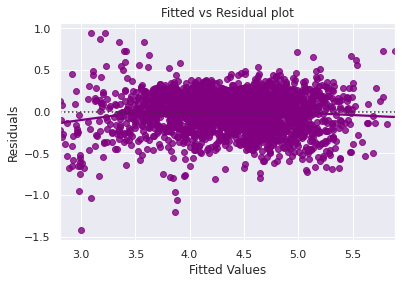

```python
# let's plot the fitted values vs residuals

sns.residplot(
    data=df_pred, x="Fitted Values", y="Residuals", color="purple", lowess=True
)
plt.xlabel("Fitted Values")
plt.ylabel("Residuals")
plt.title("Fitted vs Residual plot")
plt.show()
```

- The scatter plot shows the distribution of residuals (errors) vs fitted values (predicted values).
- If there exist any pattern in this plot, we consider it as signs of non-linearity in the data and a pattern means that the model doesn't capture non-linear effects.
- **We see no pattern in the plot above. Hence, the assumptions of linearity and independence are satisfied.**

### 3. TEST FOR NORMALITY

*Student Note : Make reference to SLF_MLS2_AnimeRatings.ipynb*

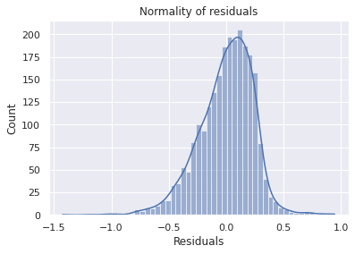

```python
sns.histplot(data=df_pred, x="Residuals", kde=True)
plt.title("Normality of residuals")
plt.show()
```

- The histogram of residuals does have a bell shape.
- Let's check the Q-Q plot.

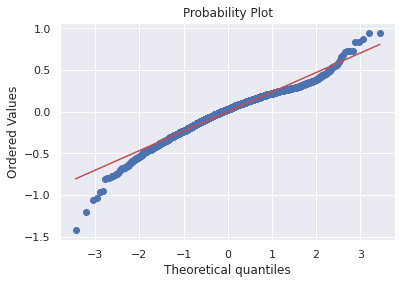

```python
stats.probplot(df_pred["Residuals"], dist="norm", plot=pylab)
plt.show()
```

- The residuals more or less follow a straight line except for the tails.
- Let's check the results of the Shapiro-Wilk test.

```python
stats.shapiro(df_pred["Residuals"])
```

```
ShapiroResult(statistic=0.9713722467422485, pvalue=1.4167602584471255e-21)
```

**Observations:**

- Since p-value < 0.05, the residuals are not normal as per the Shapiro-Wilk test.
- However, as an approximation, we can accept this distribution as close to being normal.

**So, the assumption is satisfied.**

### 4. **TEST FOR HOMOSCEDASTICITY**

- **Homoscedascity**: If the variance of the residuals is symmetrically distributed across the regression line, then the data is said to be homoscedastic.
- **Heteroscedascity**: If the variance is unequal for the residuals across the regression line, then the data is said to be heteroscedastic.

```python
name = ["F statistic", "p-value"]
test = sms.het_goldfeldquandt(df_pred["Residuals"], x_train3)
lzip(name, test)
```

```
[('F statistic', 1.0379816236698063), ('p-value', 0.25942211282591765)]
```

**Since p-value > 0.05, we can say that the residuals are homoscedastic. So, this assumption is satisfied.**

## Predictions on test data

*Now that we have checked all the assumptions of linear regression and they are satisfied, let's go ahead with prediction.*

```python
# predictions on the test set
pred = olsmod2.predict(x_test3)

df_pred_test = pd.DataFrame({"Actual": y_test, "Predicted": pred})
df_pred_test.sample(10, random_state=1)
```

|  | Actual | Predicted |
| --- | --- | --- |
| 1995 | 4.566741 | 4.394856 |
| 2341 | 3.696103 | 3.940596 |
| 1913 | 3.592093 | 3.724631 |
| 688 | 4.306495 | 4.139734 |
| 650 | 4.522115 | 5.122717 |
| 2291 | 4.259294 | 4.402125 |
| 40 | 4.997685 | 5.291063 |
| 1884 | 3.875359 | 4.068264 |
| 2538 | 4.206631 | 3.983977 |
| 45 | 5.380450 | 5.390131 |

From the given table, we can observe that the predicted values are generally close to the actual values, but there are some differences. For example, for the fifth data point, the predicted value is significantly higher than the actual value.

## Final Model

Let's recreate the final model and print it's summary to gain insights. As noted above, we shall consider the features in x_train3 as the final set of predictor variables and olsmod2 as final model to move forward with

```python
x_train_final = x_train3.copy()
x_test_final = x_test3.copy()
```

```python
olsmodel_final = sm.OLS(y_train, x_train_final).fit()
print(olsmodel_final.summary())
```

```
                              OLS Regression Results
=================================================================================
Dep. Variable:     normalized_used_price   R-squared:                       0.834
Model:                               OLS   Adj. R-squared:                  0.834
Method:                    Least Squares   F-statistic:                     1346.
Date:                   Fri, 17 Mar 2023   Prob (F-statistic):               0.00
Time:                           15:36:36   Log-Likelihood:                 43.821
No. Observations:                   2417   AIC:                            -67.64
Df Residuals:                       2407   BIC:                            -9.740
Df Model:                              9
Covariance Type:               nonrobust
========================================================================================
                           coef    std err          t      P>|t|      [0.025      0.975]
----------------------------------------------------------------------------------------
const                    0.4881      0.024     20.559      0.000       0.442       0.535
const                    0.4881      0.024     20.559      0.000       0.442       0.535
screen_size              0.0427      0.004     12.161      0.000       0.036       0.050
main_camera_mp           0.0215      0.002     13.882      0.000       0.018       0.024
selfie_camera_mp         0.0173      0.002     11.272      0.000       0.014       0.020
int_memory               0.0004      0.000      2.281      0.023    5.58e-05       0.001
ram                      0.0192      0.004      4.322      0.000       0.010       0.028
weight                   0.0015      0.000      6.386      0.000       0.001       0.002
normalized_new_price     0.4056      0.011     36.707      0.000       0.384       0.427
os_Others               -0.0734      0.028     -2.620      0.009      -0.128      -0.018
4g_yes                   0.0443      0.014      3.176      0.002       0.017       0.072
==============================================================================
Omnibus:                      218.299   Durbin-Watson:                   1.935
Prob(Omnibus):                  0.000   Jarque-Bera (JB):              427.241
Skew:                          -0.596   Prob(JB):                     1.68e-93
Kurtosis:                       4.679   Cond. No.                     4.87e+16
==============================================================================

Notes:
[1] Standard Errors assume that the covariance matrix of the errors is correctly specified.
[2] The smallest eigenvalue is 3.27e-26. This might indicate that there are
strong multicollinearity problems or that the design matrix is singular.
```

```python
# checking model performance on train set (seen 70% data)
print("Training Performance\n")
olsmod2_train_perf = model_performance_regression(olsmodel_final, x_train3, y_train)
olsmod2_train_perf
```

```
Training Performance
```

|  | RMSE | MAE | R-squared | Adj. R-squared | MAPE |
| --- | --- | --- | --- | --- | --- |
| 0 | 0.237623 | 0.183947 | 0.834266 | 0.833508 | 4.433678 |

```python
# checking model performance on test set (seen 30% data)
print("Test Performance\n")
olsmod2_test_perf = model_performance_regression(olsmodel_final, x_test3, y_test)
olsmod2_test_perf
```

```
Test Performance
```

|  | RMSE | MAE | R-squared | Adj. R-squared | MAPE |
| --- | --- | --- | --- | --- | --- |
| 0 | 0.24467 | 0.188737 | 0.834026 | 0.832244 | 4.61975 |

Summary of Final Model

- The model is able to explain ~83% of the variation in the data, which is well good.
- The MAPE (Mean Absolute Percentage Error) is a measure of the accuracy of a model in predicting values. This indicates that, on average, the model's predictions for the normalized used price of ReCell's used devices have an absolute percentage error of approximately 4.62%

Hence, we can conclude the model olsmod2 is good for prediction as well as inference purposes.

## Insights

**SUMMARY**

To develop a dynamic *pricing strategy for used and refurbished devices*, we can use a linear regression model to predict the price of a used phone/tablet and identify factors that significantly influence it. We can use the features provided in the dataset furnished to us such as brand name, OS, screen size, 4G/5G availability, camera resolution, internal memory, RAM, battery capacity, weight, release year, and days as the independent variables, and normalized used price as the dependent variable.

We have used statistical techniques such as correlation analysis, hypothesis testing, and regression analysis to identify the factors that significantly influence the price of used and refurbished devices for ReCell.

*Note : All price mentioned are in Euros*

**Exploratory Data Analytics (EDA)**

I shall present only some of the *relevant insights related to pricing strategy* for used and refurbished devices.

From the graphical analysis carried out, we observe that :

**1. Used Device Price**

From a business perspective, this information is useful because it suggests that ReCell can forecast/predict the demand for used product with greater accuracy and confidence as the risk of doing this is also low and that the market for these products is relatively stable

**2. New Device Price**

- The average value of new price devices is 5.23 Euro, the minimum value is approximately 2.90 Euro, while the maximum value is approximately 7.85 Euro

ReCell can use this information to determine the most common price range for new products and adjust their pricing strategy accordingly to maximize sales and revenue.

**3. No of Days Used**

- The average number of days is approximately 675 days. This means on average, the products have been used for around 2 years before being resold.
- The standard deviation is approximately 249 days which indicates that there is a significant amount of variability in the number of days the product has been used. This suggests that some products may be in better condition than others, and that the resale value of each product may vary based on its condition.

This information can be used by ReCell to determine the resale value of each product based on its age and condition. For example, products that have been used for a shorter duration are likely to be in better condition and may be priced higher than products that have been used for a longer duration.

**4. Release Year**

- The minimum and maximum values of 2013 and 2020 respectively suggest that the products available for resale by ReCell range from 1 to 8 years old.

From a business perspective, this information can be used by ReCell to adjust their pricing strategy based on the age of the product. For example, products that were released more recently may be priced higher than older models. Additionally, understanding the distribution of the "release_year" variable can help ReCell to adjust their inventory management strategy, such as focusing on stocking up on newer models and phasing out older models.

**5. Operating System & Brand Value**

From a business perspective, this information can be used by ReCell to make adjustment to their pricing and promotion strategy based on brand purchasing power particularly for brands that have a lower normalized used price.

## **RECOMMENDATIONS**

**ADDITIONAL RECCOMENDATIONS**

The data on release year and years since release can provide valuable insights for ReCell's business analysis. Overall, the data on release year and years since release can help ReCell make data-driven decisions about its product development, pricing, and inventory management strategies.

1. *Product lifecycle analysis:* The data on release year and years since release can be used to analyze the product lifecycle of ReCell's products. By looking at the distribution of release years and the distribution of years since release, ReCell can identify trends in product development and release.
2. *Pricing strategy:* The data on release year and years since release can also inform ReCell's pricing strategy. As products get older, they generally become less valuable and less expensive. By analyzing the relationship between years since release and product price, ReCell can develop a pricing strategy that takes into account the product lifecycle and the decreasing value of older products.
3. *Inventory management:* The data on release year and years since release can also be used to inform ReCell's inventory management. Products that are older and have been on the market longer may be more difficult to sell, so ReCell may want to adjust its inventory levels accordingly. Additionally, ReCell may want to prioritize the sale of older products by offering discounts or other incentives to customers.

**Factors that can significantly influence the price of used and refurbished devices and affect customer satisfaction. Here are some key factors that ReCell can focus on to attract more customers and increase customer satisfaction:**

1. Accessories and packaging: The inclusion of accessories such as chargers, headphones, and original packaging can add value to the device and make it more attractive to buyers.
2. Warranty and return policy: Offering a warranty and return policy can increase customer satisfaction and confidence in the product, leading to higher sales.
3. Market demand: The demand for a particular device can fluctuate depending on factors such as trends, seasonal demand, and availability. ReCell can monitor market trends and adjust their pricing accordingly to maximize sales.
4. Competitor pricing: Monitoring competitor pricing can also help ReCell determine the appropriate price point for their products and remain competitive in the market.
5. Digital Marketing: Positive reviews and a good reputation can help build customer trust and increase sales.

## **CONCLUSION**

From a business context, the forecasted growth of the used phone market and the potential for cost-effective alternatives to new models provide a significant opportunity for ReCell. Developing a dynamic pricing strategy based on machine learning algorithms can help ReCell to stay competitive in the market and maximize its profits.

A well-calibrated pricing strategy that considers the factors that significantly influence the price of used and refurbished devices can help ReCell attract more customers and increase customer satisfaction. Moreover, a dynamic pricing strategy will also help ReCell to adjust the prices according to market demand and stay ahead of the competition.